# Modeling Hromada Preparedness

Andriy Koval

Last updated: 2022-12-16

*Important Definitions*

> Research Sample: Hromadas who responded to the survey.

# Environment

> Reviews the components of the working environment of the report. Non-technical readers are welcomed to skip. Come back if you need to understand the origins of custom functions, scripts, or data objects.

**Packages used**

Packages used in current report

```r
# Choose to be greedy: load only what's needed
# Three ways, from least (1) to most(3) greedy:
# -- 1.Attach these packages so their functions don't need to be qualified:
# http://r-pkgs.had.co.nz/namespace.html#search-path
library(ggplot2)   # graphs
library(forcats)   # factors
library(stringr)   # strings
library(lubridate) # dates
library(labelled)  # labels
library(dplyr)     # data wrangling
library(tidyr)     # data wrangling
# -- 2.Import only certain functions of a package into the search path.
import::from("magrittr", "%>%")
# -- 3. Verify these packages are available on the machine, but their functions need to be qualified
requireNamespace("readr"    )# data import/export
requireNamespace("readxl"   )# data import/export
requireNamespace("janitor"  )# tidy data
requireNamespace("testit"   )# For asserting conditions meet expected patterns.

pacman::p_load(tidyr,dplyr, ggplot2)
library(tidyverse)
library(readr)
library(readxl)
library(survey)
library(fastDummies)
library(gt)
```

**External scripts**

Collection of custom functions used in current repository (`sda-information-requests`)

```r
base::source("./scripts/common-functions.R")             # basics
base::source("./scripts/graphing/graph-presets.R")       # font size, colors etc
base::source("./scripts/operational-functions.R")        # quick specific functions
base::source("./scripts/binary-categorical-functions.R") # graphing and modeling
```

**Global values**

Values used throughout the report.

```r
# printed figures will go here:
prints_folder <- paste0("./analysis/survey-prep-model/prints")
if (!fs::dir_exists(prints_folder)) { fs::dir_create(prints_folder) }

data_cache_folder <- prints_folder # to sink modeling steps
```

**Functions**

Custom functions defined for use in this report.

```r
'%ni%' <- Negate(`%in%`)


make_corr_matrix <- function(d,na_action="remove", method="pearson"){

  item_names <- names(d)
  # browser()
  d1 <-
    d %>%
    select(all_of(item_names)) %>%
    mutate(
      across(
        .cols = everything()
        ,.fns = ~as.numeric(.)
      )
    )

  if(na_action == "remove"){
    d2 <- d1 %>% drop_na()
  }

  if(na_action == "replace"){
    d2 <-
      d1 %>%
      mutate(
        across(
          .cols = everything()
          ,.fns = ~replace_na(.,0L)
        )
      )
  }
  cormat <- cor(d2,method = method)
  # row.names(cormat) <- item_names
  return(cormat)
}


make_corr_plot <- function (
    corr,
    lower="number",
    upper="number",
    bg="white",
    addgrid.col="gray"
    ,title
    , ...
){
  corrplot::corrplot(
    corr
    , add=F
    , type   = "lower"
    , method = lower
    , diag   = TRUE
    , tl.pos = "lt"
    , cl.pos = "n"
    # ,order = "hclust"
    # ,addrect = 3
    ,...
  )
  corrplot::corrplot(
    corr
    ,add=T
    , type="upper"
    , method=upper
    , diag=TRUE
    , tl.pos="n"
    # ,order = "hclust"
    # ,addrect = 3
    ,title = title
    , ...
  )

}
```

# Data

## Input

```r
ds_survey <- readxl::read_excel("./data-private/derived/survey_hromadas_clean.xlsx")

# the product of ./manipulation/ellis-general.R
ds_general <- readr::read_csv("./data-private/derived/full_dataset.csv")

# meta_oblast <- googlesheets4::read_sheet(sheet_name,"choices",skip = 0)
# Originally, we pulled the meta data object from Kobo front end and stored to
# survey_xls  <- readxl::read_excel("./data-private/raw/kobo.xlsx", sheet = "survey")
# we put this on google drive now, to control manually
googlesheets4::gs4_deauth() # to indicate there is no need for a access token
# https://googlesheets4.tidyverse.org/
# https://docs.google.com/spreadsheets/d/1GaP92b7P1AI5nIYmlG0XoKYVV9AF4PDV8pVW3IeySFo/edit?usp=sharing
survey_url <- "1GaP92b7P1AI5nIYmlG0XoKYVV9AF4PDV8pVW3IeySFo"
meta_survey <- googlesheets4::read_sheet(survey_url,"survey",skip = 0)
meta_choices <- googlesheets4::read_sheet(survey_url,"choices",skip = 0)
```

**click to glimpse**

```r
ds_general %>% glimpse(80)
```

```
Rows: 1,469
Columns: 84
$ hromada_code              <chr> "UA05020010000053508", "UA05020030000031457"~
$ hromada_name              <chr> "Агрономічна", "Вінницька", "Вороновицька", ~
$ raion_code                <chr> "UA05020000000026686", "UA05020000000026686"~
$ raion_name                <chr> "Вінницький", "Вінницький", "Вінницький", "В~
$ oblast_code               <chr> "UA05000000000010236", "UA05000000000010236"~
$ oblast_name               <chr> "Вінницька", "Вінницька", "Вінницька", "Вінн~
$ type                      <chr> "сільська", "міська", "селищна", "міська", "~
$ hromada_full_name         <chr> "Агрономічна сільська громада", "Вінницька м~
$ oblast_center             <dbl> 0, 1, 0, 0, 0, 0, 0, 0, 0, 0, 0, 0, 0, 0, 0,~
$ hromada_center_code       <chr> "UA05020010010058853", "UA05020030010063857"~
$ hromada_center            <chr> "Агрономічне", "Вінниця", "Вороновиця", "Гні~
$ lat_center                <dbl> 49.19277, 49.23202, 49.11179, 49.09337, 49.1~
$ lon_center                <dbl> 28.37203, 28.46797, 28.68894, 28.33834, 29.2~
```

[output cut: 71 more lines]

```r
ds_survey %>% glimpse(80)
```

```
Rows: 138
Columns: 277
$ index                                              <dbl> 2, 3, 5, 6, 7, 8, 9~
$ today                                              <dttm> 2022-10-12, 2022-1~
$ `_id`                                              <dbl> 191541757, 19156022~
$ hromada_code                                       <chr> "UA1206019000004351~
$ hromada_name                                       <chr> "Лозуватська", "Пус~
$ hromada_full_name                                  <chr> "Лозуватська сільсь~
$ raion_code                                         <chr> "UA1206000000002263~
$ raion_name                                         <chr> "Криворізький", "Ль~
$ oblast_code                                        <chr> "UA1200000000009047~
$ oblast_name                                        <chr> "Дніпропетровська",~
$ type                                               <chr> "сільська", "міська~
$ occupation                                         <chr> "not_occupied", NA,~
$ military_action                                    <chr> "no_combat", NA, "n~
```

[output cut: 264 more lines]

Next, we define useful sets of variable names to be used throughout the report

**click to see the groups**

```r
# create supporting objects for convenient reference of variable groups

# multiple choice questions
mcq <-
  meta_survey%>%
  dplyr::select(type,name)%>%
  dplyr::filter(str_detect(type, "select_multiple"))%>%
  dplyr::select(name)%>%
  pull() %>%
  print()
```

```
 [1] "help_for_military"             "evacuation_actions"            "idp_help"
 [4] "special_fund_relocation_needs" "bussiness_stimules"            "hromada_cooperation"
 [7] "hromada_problem_inv_labels"    "hromada_problem_info"          "hromada_problem_consultation"
[10] "hromada_problem_proposition"   "hromada_problem_system"        "hromada_problem_feedback"
[13] "hromada_problem_execution"     "skills_needed"
```

```r
#vectors of mcq names
preparation <-
  ds_survey %>%
  select(starts_with("prep_"), -prep_winter_count, -prep_count) %>%
  colnames() %>%
  print()
```

```
 [1] "prep_first_aid_water"            "prep_first_aid_fuel"
 [3] "prep_reaction_plan"              "prep_evacuation_plan"
 [5] "prep_reaction_plan_oth_hromadas" "prep_reaction_plan_oda"
 [7] "prep_dftg_creation"              "prep_national_resistance"
 [9] "prep_starosta_meeting"           "prep_communal_meetiing"
[11] "prep_online_map"                 "prep_shelter_list"
[13] "prep_notification_check"         "prep_backup"
[15] "prep_partly_backup"
```

```r
comm_channels <-
  ds_survey %>%
  select(telegram:hotline) %>%
  colnames() %>%
  print()
```

```
[1] "telegram"  "viber"     "facebook"  "chat_help" "hotline"
```

```r
idp_help <-
  ds_survey %>%
  select(starts_with('idp_help/'), -ends_with('number')) %>%
  colnames() %>%
  print()
```

```
[1] "idp_help/communal_placement" "idp_help/private_placement"  "idp_help/regular_meal"
[4] "idp_help/humanitar_help"     "idp_help/fundraising"        "idp_help/employ"
[7] "idp_help/psych_help"         "idp_help/law_help"           "idp_help/transit_center"
```

```r
military_help <-
  ds_survey %>%
  select(starts_with('help_for_military/')) %>%
  colnames() %>%
  print()
```

```
[1] "help_for_military/rooms"     "help_for_military/transport" "help_for_military/money"
[4] "help_for_military/products"  "help_for_military/other"
```

```r
# only for occupied hromadas - few cases
hromada_cooperation <-
  ds_survey %>%
  select(starts_with('hromada_cooperation/')) %>%
  colnames() %>%
  print()
```

```
[1] "hromada_cooperation/medicine"   "hromada_cooperation/food"
[3] "hromada_cooperation/pensions"   "hromada_cooperation/evacuation"
[5] "hromada_cooperation/other"      "hromada_cooperation/none"
```

```r
prep_for_winter <- c('info_campaign', 'reserves', 'count_power_sources',
                     'count_heaters_need', 'solid_fuel_boiler')
# vector of income variables
income <-
  ds_survey %>%
  select(ends_with('capita'), ends_with('prop_2021')) %>%
  colnames() %>%
  print()
```

```
[1] "own_income_prop_2021"   "transfert_prop_2021"    "military_tax_prop_2021"
[4] "pdfo_prop_2021"         "unified_tax_prop_2021"  "property_tax_prop_2021"
[7] "excise_duty_prop_2021"
```

**meta data**

```r
meta_survey %>% glimpse()
```

```
Rows: 132
Columns: 14
$ group              <chr> NA, NA, NA, NA, NA, NA, "preamble", "general_information", "general_inf~
$ item_number        <dbl> NA, NA, NA, NA, NA, NA, NA, NA, NA, NA, NA, NA, NA, NA, NA, NA, NA, NA,~
$ label_en           <chr> NA, NA, NA, NA, NA, NA, NA, NA, NA, NA, NA, NA, NA, NA, NA, NA, NA, NA,~
$ label_ua           <chr> NA, NA, NA, NA, NA, NA, NA, NA, NA, NA, NA, NA, NA, NA, NA, NA, NA, NA,~
$ type               <chr> "start", "end", "today", "deviceid", "begin_group", "begin_group", "not~
$ name               <chr> "start", "end", "today", "deviceid", "general_information", "general_in~
$ label              <chr> NA, NA, NA, NA, NA, NA, "Супротив України у загарбницькій війні Російсь~
$ required           <list> <NULL>, <NULL>, <NULL>, <NULL>, <NULL>, "field-list", <NULL>, TRUE, TR~
$ appearance         <chr> NA, NA, NA, NA, NA, NA, NA, NA, NA, NA, NA, NA, NA, NA, NA, NA, NA, NA,~
$ `media::image`     <chr> NA, NA, NA, NA, NA, NA, "kse_institute.png", NA, NA, NA, NA, NA, NA, NA~
$ relevant           <chr> NA, NA, NA, NA, NA, NA, NA, NA, NA, NA, NA, NA, NA, NA, NA, NA, NA, NA,~
$ constraint         <chr> NA, NA, NA, NA, NA, NA, NA, NA, NA, NA, NA, NA, NA, NA, NA, NA, NA, NA,~
$ constraint_message <chr> NA, NA, NA, NA, NA, NA, NA, NA, NA, NA, NA, NA, NA, NA, NA, NA, NA, NA,~
$ hint               <chr> NA, NA, NA, NA, NA, NA, "Заповнення опитувальника займе орієнтовно 25 х~
```

```r
meta_survey %>%
  filter(type %in% c("begin_group","end_group")) %>%
  select(type, name) %>%
  print_all()
```

```
# A tibble: 32 x 2
   type        name
   <chr>       <chr>
 1 begin_group general_information
 2 begin_group general_information_text
 3 end_group   general_information_text
 4 end_group   general_information
 5 begin_group preparation
 6 end_group   preparation
 7 begin_group information
 8 end_group   information
 9 begin_group national_resistance
10 begin_group transport_help
11 end_group   transport_help
12 end_group   national_resistance
```

[output cut: 20 more lines]

```r
meta_survey %>% glimpse()
```

```
Rows: 132
Columns: 14
$ group              <chr> NA, NA, NA, NA, NA, NA, "preamble", "general_information", "general_inf~
$ item_number        <dbl> NA, NA, NA, NA, NA, NA, NA, NA, NA, NA, NA, NA, NA, NA, NA, NA, NA, NA,~
$ label_en           <chr> NA, NA, NA, NA, NA, NA, NA, NA, NA, NA, NA, NA, NA, NA, NA, NA, NA, NA,~
$ label_ua           <chr> NA, NA, NA, NA, NA, NA, NA, NA, NA, NA, NA, NA, NA, NA, NA, NA, NA, NA,~
$ type               <chr> "start", "end", "today", "deviceid", "begin_group", "begin_group", "not~
$ name               <chr> "start", "end", "today", "deviceid", "general_information", "general_in~
$ label              <chr> NA, NA, NA, NA, NA, NA, "Супротив України у загарбницькій війні Російсь~
$ required           <list> <NULL>, <NULL>, <NULL>, <NULL>, <NULL>, "field-list", <NULL>, TRUE, TR~
$ appearance         <chr> NA, NA, NA, NA, NA, NA, NA, NA, NA, NA, NA, NA, NA, NA, NA, NA, NA, NA,~
$ `media::image`     <chr> NA, NA, NA, NA, NA, NA, "kse_institute.png", NA, NA, NA, NA, NA, NA, NA~
$ relevant           <chr> NA, NA, NA, NA, NA, NA, NA, NA, NA, NA, NA, NA, NA, NA, NA, NA, NA, NA,~
$ constraint         <chr> NA, NA, NA, NA, NA, NA, NA, NA, NA, NA, NA, NA, NA, NA, NA, NA, NA, NA,~
$ constraint_message <chr> NA, NA, NA, NA, NA, NA, NA, NA, NA, NA, NA, NA, NA, NA, NA, NA, NA, NA,~
$ hint               <chr> NA, NA, NA, NA, NA, NA, "Заповнення опитувальника займе орієнтовно 25 х~
```

## Transformations

For the state `ds0`, we augment the focal table of the report with additional columns and transform existing variable to better fit visualization/modeling needs

```r
ds_general0 <-
  ds_general %>%
  mutate(
    survey_response = case_when(
      hromada_code %in% (ds_survey %>% pull(hromada_code) %>% unique()) ~ TRUE
      ,TRUE ~ FALSE
    )
  )
# ds_general0 %>% group_by(survey_response) %>% count()



ds0 <-
  ds_survey %>%
  mutate(
    income_own_per_capita       = income_own_2021         / total_population_2022,
    income_total_per_capita     = income_total_2021       / total_population_2022,
    income_tranfert_per_capita  = income_transfert_2021   / total_population_2022,
    idp_registration_share      = idp_registration_number / total_population_2022,
    idp_real_share              = idp_real_number         / total_population_2022,
    idp_child_share             = idp_child_education     / idp_registration_number
  ) %>%
  left_join(ds_general %>% select(hromada_code, train_station, passangers_2021),
            by = 'hromada_code')

ds0 %>% glimpse(80)
```

```
Rows: 138
Columns: 285
$ index                                              <dbl> 2, 3, 5, 6, 7, 8, 9~
$ today                                              <dttm> 2022-10-12, 2022-1~
$ `_id`                                              <dbl> 191541757, 19156022~
$ hromada_code                                       <chr> "UA1206019000004351~
$ hromada_name                                       <chr> "Лозуватська", "Пус~
$ hromada_full_name                                  <chr> "Лозуватська сільсь~
$ raion_code                                         <chr> "UA1206000000002263~
$ raion_name                                         <chr> "Криворізький", "Ль~
$ oblast_code                                        <chr> "UA1200000000009047~
$ oblast_name                                        <chr> "Дніпропетровська",~
$ type                                               <chr> "сільська", "міська~
$ occupation                                         <chr> "not_occupied", NA,~
$ military_action                                    <chr> "no_combat", NA, "n~
```

[output cut: 272 more lines]

**show transformations**

```r
# compute total binary score (preparations are made at all, regardless of timing)
d_meta_prep <-
  meta_survey %>%
  filter(group=="preparation") %>%
  select(item_name = name,label_en,label)

ds1_prep <-
  ds0 %>%
  mutate(
    # sum of 0|1|2 where larger numbers indicate more preparedness
    prep_score_combo = rowSums(across(all_of(preparation)),na.rm = T)
    ,prep_score_feb = rowSums(
      across(
        .cols = preparation
        ,.fns = ~case_when(
          .  == 0 ~ 0 #"No"
          ,. == 1 ~ 0 #"After Feb 24"
          ,. == 2 ~ 1 #"Before Feb 24"
        )
      )
      ,na.rm = T
    )
    ,prep_score_oct = rowSums(
      across(
        .cols = preparation
        ,.fns = ~case_when(
          .  == 0 ~ 0 #"No"
          ,. == 1 ~ 1 #"After Feb 24"
          ,. == 2 ~ 1 #"Before Feb 24"
        )
      )
      ,na.rm = T
    )
  )  %>%
  select(hromada_code, starts_with("prep_score"),preparation)
ds1_prep %>% select(1:4)
```

```
# A tibble: 138 x 4
   hromada_code        prep_score_combo prep_score_feb prep_score_oct
   <chr>                          <dbl>          <dbl>          <dbl>
 1 UA12060190000043514               23             10             13
 2 UA46060370000065608               14              4             10
 3 UA35060190000079777               16              3             13
 4 UA35020130000045875               14              2             12
 5 UA53060250000043118               20              6             14
 6 UA65060250000073379               13              6              7
 7 UA51040110000040346                9              1              8
 8 UA59080230000084731               10              0             10
 9 UA05100110000070795               12              0             12
10 UA51100250000055079               10              0             10
# ... with 128 more rows
```

```r
## Some handy datasets for quick visualization
# Raw scale (0,1,2) with factors
ds1_prep_ordinal_factors <-
  ds1_prep %>%
  mutate(
    across(
      .cols = preparation
      ,.fns = ~case_when(
        . == 0  ~ "No"
        ,. == 1 ~ "As of Oct"
        ,. == 2 ~ "As of Feb"
        ,TRUE   ~ "Not Applicable"
      ) %>% factor(levels=c("No","As of Oct","As of Feb",  "Not Applicable"))
    )
  ) %>%
  select(hromada_code, starts_with("prep_score"),preparation)

# Binary scale (0,1) with factors
ds1_prep_binary_factors <-
  ds1_prep %>%
  mutate(
    across(
      .cols = preparation
      ,.fns = ~case_when(
        .  == 0  ~ "No"
        ,. == 1 ~ "Yes"
        ,. == 2 ~ "Yes"
        ,TRUE   ~ "Not Applicable"
      ) %>% factor(levels=c("No","Yes","Not Applicable"))
    )
  ) %>%
  select(hromada_code, starts_with("prep_score"),preparation)
```

**examine the versions**

# Variable List

The following variables are present in the processed data table of survey responses:

```r
ds0 %>% explore::describe_all() %>%neat_DT()
```

|  | variable | type | na | na_pct | unique | min | mean | max |
| --- | --- | --- | --- | --- | --- | --- | --- | --- |
| 1 | index | dbl | 0 | 0 | 138 | 2 | 78.2 | 151 |
| 2 | today | dat | 0 | 0 | 30 |  |  |  |
| 3 | _id | dbl | 0 | 0 | 138 | 191541757 | 197322877.2 | 206471695 |
| 4 | hromada_code | chr | 0 | 0 | 138 |  |  |  |
| 5 | hromada_name | chr | 0 | 0 | 135 |  |  |  |
| 6 | hromada_full_name | chr | 0 | 0 | 137 |  |  |  |
| 7 | raion_code | chr | 0 | 0 | 76 |  |  |  |
| 8 | raion_name | chr | 0 | 0 | 76 |  |  |  |
| 9 | oblast_code | chr | 0 | 0 | 22 |  |  |  |
| 10 | oblast_name | chr | 0 | 0 | 22 |  |  |  |

[output cut: 275 more lines]

# 0. Introduction

0.1 What is the goal of this report?

# 1. General Information

```r
meta_survey %>% filter(group=="preamble") %>% pull(label) %>% cat()
```

```
Супротив України у загарбницькій війні Російської Федерації великою мірою пов’язаний зі стійкістю, яку виявили територіальні громади.
Щоб оцінити, як різні потрясіння вплинули на громади та перевірити, які фактори впливають на стійкість громад у війні, Київська Школа Економіки проводить опитування.
Ми гарантуємо конфіденційність Ваших відповідей. Всі отримані дані будуть аналізуватись тільки в узагальненому вигляді.
Крайній термін заповнення анкети - 4 листопада.
```

1.1 How many hromadas contributed responses to so far?

> As of 2022-12-16, 138 hromadas contributed valid response to the survey

1.2 What oblasts are represented in this sample>?

```r
ds_survey %>%
  group_by(region_en, oblast_name_en) %>%
  summarize(
    hormada_count = n_distinct(hromada_code)
    ,.groups = "drop"
  ) %>%
  left_join(
    ds_general %>%
      group_by(region_en,  oblast_name_en) %>%
      summarize(hromada_count_total = n())
  ) %>%
  mutate(
    prop = hormada_count/hromada_count_total
    ,pct = scales::percent(prop, accuracy = .1)
  ) %>%
  arrange(region_en, oblast_name_en) %>%
  select(-prop) %>%
  ungroup() %>%
  # neat_DT()
  neat()
```

| region_en | oblast_name_en | hormada_count | hromada_count_total | pct |
| --- | --- | --- | --- | --- |
| Center | Cherkassy | 5 | 66 | 7.6% |
| Center | Khmelnitsk | 1 | 60 | 1.7% |
| Center | Kirovograd | 5 | 49 | 10.2% |
| Center | Poltava | 8 | 60 | 13.3% |
| Center | Vinnytsia | 5 | 63 | 7.9% |
| East | Driproptrovska | 12 | 86 | 14.0% |
| East | Kharkiv | 4 | 56 | 7.1% |
| East | Zaporizka | 3 | 67 | 4.5% |
| North | Chernigiv | 7 | 57 | 12.3% |
| North | Kyiv-oblast | 5 | 69 | 7.2% |
| North | Sumska | 8 | 51 | 15.7% |
| North | Zhytomir | 3 | 66 | 4.5% |
| South | Kherson | 7 | 49 | 14.3% |
| South | Mykolayiv | 1 | 52 | 1.9% |
| South | Odesa | 12 | 91 | 13.2% |
| West | Cherniveska | 3 | 52 | 5.8% |
| West | Ivano-Frankivsk | 16 | 62 | 25.8% |
| West | Lviv | 9 | 73 | 12.3% |
| West | Rivenska | 4 | 64 | 6.2% |
| West | Ternopilska | 4 | 55 | 7.3% |
| West | Vonyn | 5 | 54 | 9.3% |
| West | Zakarpatska | 11 | 64 | 17.2% |

1.3 What type of hromadas are represented in the sample?

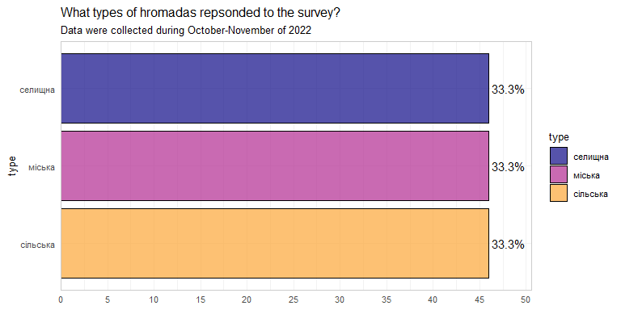

```r
(ds0 %>% make_bi_freq_graph("type"))+
  labs(
    title = "What types of hromadas repsonded to the survey?"
    ,subtitle = "Data were collected during October-November of 2022"
    ,y = NULL
  )
```

1.4 What hromadas experienced military occupation or military actions?

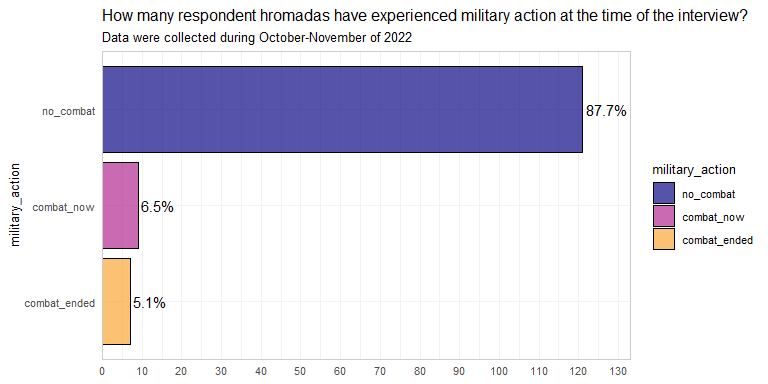

```r
(ds0 %>% make_bi_freq_graph("military_action"))+
  labs(
    title = "How many respondent hromadas have experienced military action at the time of the interview?"
    ,subtitle = "Data were collected during October-November of 2022"
    ,y = NULL
  )
```

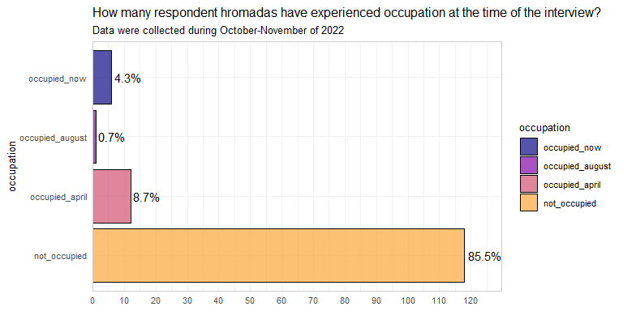

```r
(ds0 %>% make_bi_freq_graph("occupation"))+
  labs(
    title = "How many respondent hromadas have experienced occupation at the time of the interview?"
    ,subtitle = "Data were collected during October-November of 2022"
    ,y=NULL
  )
```

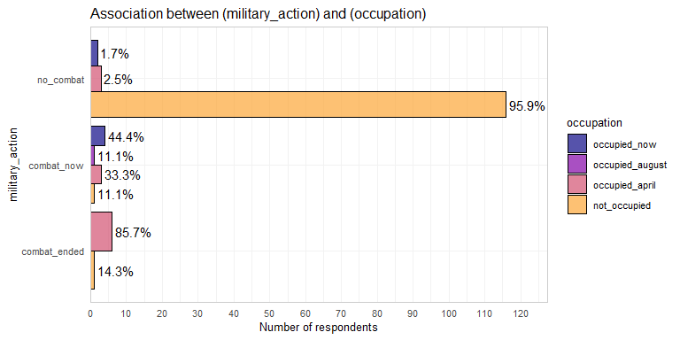

```r
ds0 %>% make_bi_freq_graph("military_action","occupation")
```

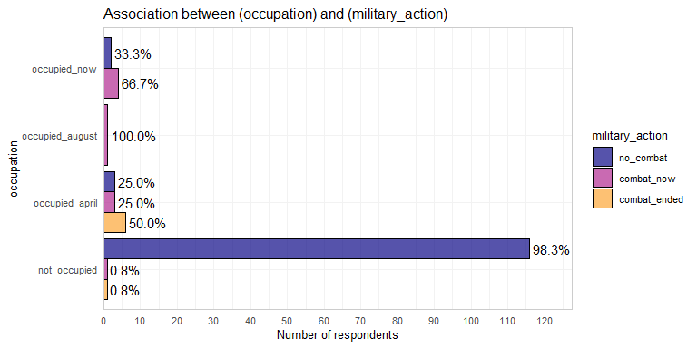

```r
ds0 %>% make_bi_freq_graph("occupation","military_action")
```

# 2. Preparation

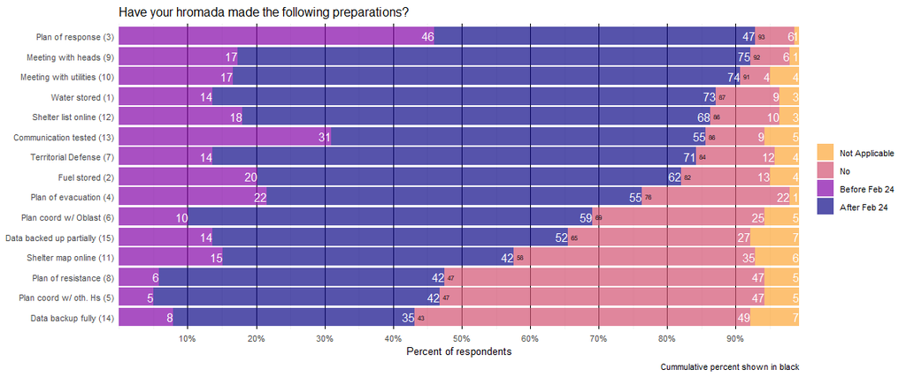

```r
d1 <-
  ds1_prep_ordinal_factors %>%
  pivot_longer(cols = preparation, names_to = "item_name") %>%
  group_by(item_name,value) %>%
  summarize(
    count = n_distinct(hromada_code)
    ,.groups = "drop"
  ) %>%
  group_by(item_name) %>%
  mutate(
    prop = count/sum(count, rm.na = T)
    ,pct = scales::percent(prop, accuracy = 1)
  ) %>%
  ungroup()

d2 <-
  ds1_prep_binary_factors %>%
  pivot_longer(cols = preparation, names_to = "item_name") %>%
  group_by(item_name,value) %>%
  summarize(
    count = n_distinct(hromada_code)
    ,.groups = "drop"
  ) %>%
  group_by(item_name) %>%
  mutate(
    prop = count/sum(count, rm.na = T)
    ,pct = scales::percent(prop, accuracy = 1)
  ) %>%
  ungroup()

d12 <-
  bind_rows(
    d1
    ,d2 %>% filter(value == "Yes")
  ) %>%
  left_join(
    d_meta_prep
  ) %>%
  arrange(item_name, value)

d_in <-
  d12 %>%
    mutate(
    display_name = label_en
    ,display_name = factor(
      display_name
      ,levels =  d12 %>%
        left_join(d_meta_prep) %>%
        filter(value == "Yes") %>%
        # filter(value == "Before Feb 24") %>%
        arrange(prop) %>%
        # arrange(desc(item_number)) %>%
        pull(label_en)
    ) # display_name
    ,value = fct_relevel(
      value
      , "Before Feb 24", "After Feb 24","Yes", "No", "Not Applicable",
    ) %>% fct_rev()
  )

g <-
  d_in %>%
  {
  ggplot(
    data = (.) %>% filter(value !="Yes") %>% mutate(value=factor(value))
    ,aes(x=prop, y = display_name, fill=value)
  )+
  geom_col(position = position_stack()
           , alpha = .7
           ,data =
  )+
  geom_text(aes(label = str_remove(pct,"\\%"))
            ,hjust = 1
            , size = 4
            ,color="white"
            ,position = position_stack()
            ,data = . %>% filter(value !="Yes")
            )+
  geom_text(aes(label = str_remove(pct,"\\%"))
            ,hjust = -.5
            ,vjust = .5
            , size = 2
            ,color="black"
            ,position = position_stack()
            ,data = (.) %>% filter(value=="Yes") %>% mutate(value=NA)

            )+
  scale_x_continuous(
    breaks = seq(.1,1,.1)
    ,labels = scales::percent_format()
    ,expand = expansion(add=c(-.000,-.0))
  )+
  scale_fill_viridis_d(
    begin = .8, end = .0, direction = -1
    , option = "plasma", guide= guide_legend(reverse=T)
  )+
  labs(
    title = "Have your hromada made the following preparations?"
    ,x = "Percent of respondents", y = NULL, fill = NULL
    ,caption = "Cummulative percent shown in black"
  )+
  theme(
    # panel.grid = element_blank()
    panel.grid.major.y  = element_blank()
    ,panel.border = element_blank()
    ,panel.grid.major.x = element_line(color = "black")
  )
  }

g
```

```r
# g %>% quick_save("2-preparation-summary-yes",w=12,h=5)
```

2.1 What questions were asked about preparations hromadas made?

```r
ds0 %>%
  select(preparation) %>%
  explore::describe_all() %>%
  left_join(
    meta_survey %>% filter(group=="preparation") %>% select(name,label_en,label)
    ,by=c("variable"="name")) %>%
  relocate(c("label_en","label"),.after = "variable") %>%
  select(1:3) %>%
  neat()
```

| variable | label_en | label |
| --- | --- | --- |
| prep_first_aid_water | Water stored (1) | Сформовані запаси товарів першої необхідності (вода, їжа, медичні засоби) |
| prep_first_aid_fuel | Fuel stored (2) | Сформовані запаси товарів першої необхідності (паливо) |
| prep_reaction_plan | Plan of response (3) | Оновлено чи затверджено план реагування на надзвичайні ситуації |
| prep_evacuation_plan | Plan of evacuation (4) | Складено спеціальний план евакуації населення при загрозі збройного конфлікту |
| prep_reaction_plan_oth_hromadas | Plan coord w/ oth. Hs (5) | Узгоджено план реагування/дій у разі повномасштабного вторгнення з представниками інших громад |
| prep_reaction_plan_oda | Plan coord w/ Oblast (6) | Узгоджено план реагування/дій у разі повномасштабного вторгнення з представниками ОДА |
| prep_dftg_creation | Territorial Defense (7) | Розпочато створення (добровольчого) формування територіальної громади |
| prep_national_resistance | Plan of resistance (8) | Затверджена та опрацьована представниками ОМС програма національного спротиву на території громади |
| prep_starosta_meeting | Meeting with heads (9) | Проведена зустріч зі старостами з приводу дій у випадку вторгнення |
| prep_communal_meetiing | Meeting with utilities (10) | Проведена зустріч з головами комунальних підприємств з приводу дій у випадку вторгнення |
| prep_online_map | Shelter map online (11) | Опублікована онлайн-мапа укриттів в громаді |
| prep_shelter_list | Shelter list online (12) | Опублікований перелік адрес укриттів в соцмережах або на сайті громади |
| prep_notification_check | Communication tested (13) | Перевірено засоби оповіщення населення |
| prep_backup | Data backup fully (14) | Здійснено повне централізоване резервне копіювання даних громади (критично важливої інформації, наприклад, даних про інфраструктуру) |
| prep_partly_backup | Data backed up partially (15) | Здійснено часткове резервне копіювання даних громади (критично важливої інформації, наприклад, даних про інфраструктуру) |

## Item-total correlation

We can conceptualize the preparation for invation as two scores: the first received for steps taken prior to Feb 24, 2022 (the `Before` prep score) and the second for the steps undertaken after Feb 24 (the `After` prep score), as recorded at the time of data collection ( October - November 20200).

```r
ds1_prep %>% select(1:4) # + individual preparation items
```

```
# A tibble: 138 x 4
   hromada_code        prep_score_combo prep_score_feb prep_score_oct
   <chr>                          <dbl>          <dbl>          <dbl>
 1 UA12060190000043514               23             10             13
 2 UA46060370000065608               14              4             10
 3 UA35060190000079777               16              3             13
 4 UA35020130000045875               14              2             12
 5 UA53060250000043118               20              6             14
 6 UA65060250000073379               13              6              7
 7 UA51040110000040346                9              1              8
 8 UA59080230000084731               10              0             10
 9 UA05100110000070795               12              0             12
10 UA51100250000055079               10              0             10
# ... with 128 more rows
```

```r
# prep_score =  0 to  30, sum of (0|1|2) for each of 15 items, 2 pts for prepping before 2022-02-24 1 pts after.
# prep_score_before = 0 to 15, sum of (0|1) items, where 1 = prepping before Feb 24
# prep_score_after = 0 to 15, sum of (0|1) items, where 1 = prepping eventually (Nov 2022)
```

These scores have a convenient conceptualization and a straightforward interpretation

- `Before` - number of preparatory items on the prep list completed before Feb 24
- `AFter` - number of preparatory steps completed by the hromada at the time of the interview
- `Total` - the sum of `Before` and `After`. Evaluates the readiness of the hromada at the time of the interview, valuing steps undertaken prior to Feb 24 twice as influential in the final score

`Before` and `After` scores have a more clear conceptualization, but th `Total` score has a more appealing distribution shape, making it more useful for statistical modeling.

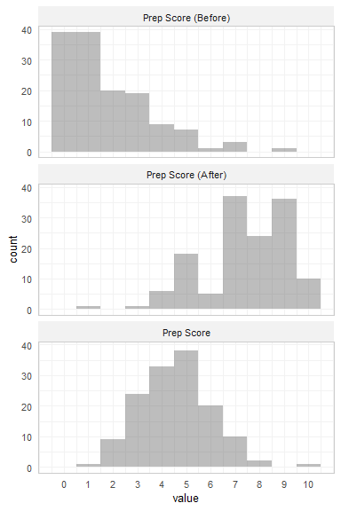

```r
g <-  ds1_prep %>%
  # To standardize the metrics of each scale : 0 to 10, where 10 - most prepared
  mutate(
     prep_score = prep_score / 3 # because 15 items, maximum 2 points each
    ,prep_score_before =prep_score_before /1.5 # because 15 items, maximum 1 point each
    ,prep_score_after = prep_score_after /1.5 # because 15 items, maximum 1 point each
  ) %>%
  select(starts_with("prep_score")) %>%
  pivot_longer(cols = everything(),names_to = "measure",values_to="value") %>%
  mutate(
    measure = factor(measure,
                        levels = c("prep_score_before","prep_score_after","prep_score")
                        ,labels = c("Prep Score (Before)","Prep Score (After)", "Prep Score")
                        )
  ) %>%
  ggplot(aes(x=value))+
  geom_histogram(binwidth = 1, alpha = .4)+
  scale_x_continuous(breaks = seq(0,10,1))+
  facet_wrap("measure",ncol =1)
g
```

```r
g %>%  quick_save("score-distribution",w=4, h=6)
```

The item-total correlation also indicates that psychometrically the `Total` score is a better choice - having no negative values and generally having a higher discrimination capacity of items.

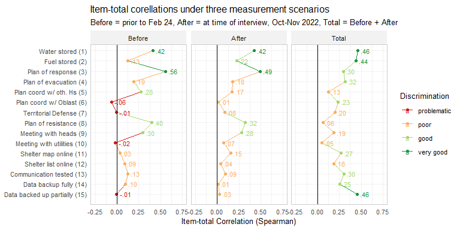

```r
(d_item_total%>%
  slice(1:15) %>%
  pivot_longer(
     cols = c("Total","Before","After")
    ,names_to = "scenario"
    ,values_to = "correlation"
  ) %>%
  mutate(
    discrimination = case_when(
      correlation <= 0  ~ "problematic"
      ,correlation > 0 & correlation < .2 ~ "poor"
      ,correlation >=.2 & correlation < .4 ~ "good"
      ,correlation >=.4  ~ "very good"
    ) %>% factor(levels = c("problematic","poor","good","very good"))
    ,scenario = scenario %>% factor(level=c("Before","After","Total"))
    ,item_name = factor(item_name, levels = d_meta_prep %>% pull(label_en)) %>%
      fct_rev()
  ) %>%
  ggplot(aes(x = item_name, y = correlation, color = discrimination, group = scenario))+
  geom_line(aes(group = "scenario"))+
  geom_point()+
  geom_text(aes(label=correlation %>% scales::number(accuracy = .01) %>% RemoveLeadingZero()),hjust=-.3
            ,size = 3)+
  geom_hline(aes(x=0, yintercept = 0))+
  facet_wrap("scenario",nrow=1)+
  scale_y_continuous(limits = c(-.3,.6), expand = expansion(add = c(0,.2)))+
  scale_color_brewer(type ="div",palette = "RdYlGn")+
  coord_flip() +
    labs(
      title = "Item-total corellations under three measurement scenarios"
      ,subtitle = "Before = prior to Feb 24, After = at time of interview, Oct-Nov 2022, Total = Before + After"
      ,y = "Item-total Correlation (Spearman)"
      ,x = NULL
      ,color = "Discrimination"
    )
  ) %>%
  print() %>%
  quick_save("item-total",w=8,h=4)
```

While all three metrics should be considered during modeling, our current understanding of the data sugggests that we should prefer the `Total` score in relating hromada’s preparedness to other attributes.

## Prep score change

```r
# Continuous - good for spreading out
comparison_vars_continuous <- c(
   "income_own_per_capita"
  ,"income_total_per_capita"
  ,"income_tranfert_per_capita"
  ,"idp_registration_share"
  ,"idp_real_share"
  ,"idp_child_share"


  ,"square"
  ,"n_settlements"
  ,"travel_time"
  ,"urban_pct"
  ,"total_population_2022"
  ,"urban_population_2022"
  ,"sum_osbb_2020"
  ,"turnout_2020"
  ,"age_head"
  ,"time_before_24th"
)
# Categorical - for color
comparison_vars_discreate <- c(
   "sex_head"
  ,"education_head"
  ,"type"
  ,"voluntary"
  ,"region_en"
)
comparison_vars <- c(
  comparison_vars_discreate
   ,comparison_vars_continuous
)

d <-
  ds1_prep %>%
  select(hromada_code, starts_with("prep_score")) %>%
  left_join(ds0 %>% select(hromada_code,all_of(comparison_vars))) %>% glimpse() %>%
  mutate(
    across(
      .cols = comparison_vars_discreate
      ,.fns = ~factor(.)
    )
  ) %>%
  pivot_longer(
    cols = comparison_vars_continuous
    ,names_to = "item_name"
    ,values_to = "item_value"
  ) %>% glimpse()

make_plot_prepvs <- function(
    d
    ,xvar    # "prep_score"
    ,yvar    # "item_value"
    ,fillvar # "region_en"
    )
{
  g <-
  d %>%
  ggplot(aes(
      x     = !!rlang::sym(xvar)
      ,y    = !!rlang::sym(yvar)
      ,fill = !!rlang::sym(fillvar)
      ))+
  ggplot2::scale_fill_viridis_d(
    begin = 0, end = .8, direction = -1
    ,option = "plasma",guide= guide_legend(reverse=T)
  )+
  facet_wrap(facets = "item_name", scales = "free_y")+
  geom_point(shape=21,color = "black", size =3, alpha = .5, position=position_jitter(seed=42))+
    labs(
      title = paste0("Relationship between Invasion Preparedness Score (horizontal) and other attributes of hromadas")
    )
}
# To see how it works
d %>%
  make_plot_prepvs(
    xvar     = "prep_score"
    ,yvar    = "item_value"
    ,fillvar = "region_en"
  )

# To execution multiple scenarios
for(i in comparison_vars_discreate){

  for(ii in c("prep_score","prep_score_before","prep_score_after")){
    g <-
      d %>%
      make_plot_prepvs(
        xvar     = ii
        ,yvar    = "item_value"
        ,fillvar = i
      )  %>%
      file_name <- paste0(ii,"-",i)
    g %>% quick_save(paste0("/1/",file_name),w=12,h=8)
    }
}
```

```r
# Continuous - good for spreading out
comparison_vars_continuous <- c(
   "income_own_per_capita"
  ,"income_total_per_capita"
  ,"income_tranfert_per_capita"
  ,"idp_registration_share"
  ,"idp_real_share"
  ,"idp_child_share"


  ,"square"
  ,"n_settlements"
  ,"travel_time"
  ,"urban_pct"
  ,"total_population_2022"
  ,"urban_population_2022"
  ,"sum_osbb_2020"
  ,"turnout_2020"
  ,"age_head"
  ,"time_before_24th"
)
# Categorical - for color
comparison_vars_discreate <- c(
   "sex_head"
  ,"education_head"
  ,"type"
  ,"voluntary"
  ,"region_en"
)
comparison_vars <- c(
  comparison_vars_discreate
   ,comparison_vars_continuous
)

d <-
  ds1_prep %>%
  select(hromada_code, starts_with("prep_score")) %>%
  left_join(ds0 %>% select(hromada_code,all_of(comparison_vars)))

d %>% glimpse()

make_plot_prep_change <- function(
  d
  ,ordervar = "prep_score"
  ,colorvar = "region_en"
){
# browser()
g <-
  d %>%
  mutate(
    hromada_code = hromada_code %>% factor() %>% fct_reorder(!!rlang::sym(ordervar))
  ) %>%
  # sample_n(10) %>%
  # slice(1:10) %>%
  ggplot(aes(y=hromada_code, color = !!rlang::sym(colorvar)))+
  geom_segment(
    aes(
      y     = hromada_code
      ,yend = hromada_code
      ,x    = prep_score_before
      ,xend = prep_score_after
      # ,x    = 0                                   # to see only after
      # ,xend = prep_score_after-prep_score_before  # to see only after
    )
    ,linewidth = 2 ,alpha = .6
  )+
  labs(
    title = paste0("The number of preparedness items secured by hromadas (N= ",
                   d %>% summarize(n=n_distinct(hromada_code)) %>% pull(n)
                   ,") before and after full scale invasion")
    ,subtitle = "Scale guide: (Before) = prior to Feb 24, (After) = at time of interview, Oct-Nov 2022, (Total) = Before + After"
    ,x = "Each segment starts at (Before) score and ends at (After)"
  )+
  # scale_color_viridis_d(
  #   begin = .8, end = .0, direction = -1
  #   , option = "plasma", guide= guide_legend(reverse=T)
  # )+
  scale_color_viridis_c(
    # begin = .8, end = .0, direction = -1
    # , option = "plasma", guide= guide_legend(reverse=T)
  )+
  # scale_color_brewer(type="qual", palette = "Dark2")+
  theme(
    axis.text.y = element_blank()
  )
return(g)
}
(
  d %>%
  make_plot_prep_change(
    ordervar = "prep_score"
    ,colorvar = "income_own_per_capita"
  )
) %>%
  quick_save("prep-change-segment-color",w=6,h=9)
```

```r
d <-
  ds1_prep %>%
  select(hromada_code, starts_with("prep_score")) %>%
  left_join(ds0 %>% select(hromada_code,all_of(comparison_vars)))

# d %>% glimpse()

make_plot_prep_change_bw <- function(
    d
  ){
  # browser()
  # level_order <- d %>% arrange(prep_score_after, prep_score_before) %>% pull(hromada_code)
  level_order <- d %>% arrange(prep_score_before, prep_score_after) %>% pull(hromada_code)

  g <-
    d %>%
    mutate(
      hromada_code = hromada_code %>% factor(levels = level_order)
    ) %>%
    ggplot(aes(y=hromada_code))+
    geom_segment(
      aes(
        y     = hromada_code
        ,yend = hromada_code
        ,x    = prep_score_before
        ,xend = prep_score_after
        # ,x    = 0                                   # to see only after
        # ,xend = prep_score_after-prep_score_before  # to see only after
      )
      ,linewidth = 2 ,alpha = .2
    )+
    labs(
      title = paste0("The number of preparedness items secured by hromadas (N= ",
                     d %>% summarize(n=n_distinct(hromada_code)) %>% pull(n)
                     ,")")
      ,subtitle = "(Before) = prior to Feb 24, (After) = at time of interview, Oct-Nov 2022"
      ,x = "Each segment starts at (Before) score and ends at (After)"
      ,caption = "Ordered by Before + After"
      # ,caption = "Ordered by After + Before"
      ,y = NULL
    )+
    theme(
      axis.text.y = element_blank()
      ,panel.grid.major.y = element_blank()
    )
  return(g)
}
(d %>%
  make_plot_prep_change_bw()
  ) %>%
   quick_save("prep-change-segment-bw-before",w=5.5,h=9)
```

# Session Information

For the sake of documentation and reproducibility, the current report was rendered in the following environment. Click the line below to expand.

Report rendered by Valentyn Hatsko at 2022-12-16, 15:45 +0200 in 8 seconds.